# UMAP: plate structure in filtered Z-score data

- Show All Code
- Hide All Code
- View Source

Published

July 14, 2026

```r
library(tidyverse)
library(umap)
library(viridis)
library(patchwork)
library(sva)

set.seed(42)

output_dir <- "out/20260714"

if (!dir.exists(output_dir)) {
  dir.create(output_dir, recursive = TRUE)
}
```

## Load Z-score matrices + plate metadata, per isotype

Sample columns in the raw Z-score TSVs include Sblk/control columns that never got a clinical/plate metadata row in `0-sample_tidy`. Inner-joining against `sample_subject_metadata_pepseq_*.tsv` on `pepseq_sn` both drops those controls and attaches `plate_id` for coloring, reusing the isotype/control filtering already done there instead of re-deriving it here.

```r
load_isotype <- function(data_path, metadata_path) {
  data_wide <- read_tsv(data_path, show_col_types = FALSE) %>%
    rename(library_member = `Sequence name`)

  metadata <- read_tsv(metadata_path, show_col_types = FALSE) %>%
    select(pepseq_sn, plate_id, subject_id, cohort)

  keep_samples <- intersect(colnames(data_wide), metadata$pepseq_sn)

  list(
    values = data_wide %>% select(library_member, all_of(keep_samples)),
    metadata = metadata %>% filter(pepseq_sn %in% keep_samples)
  )
}

igg <- load_isotype(
  "../../pepsirf_data/data_for_sharing_20250214/IM0166_IM0174_PF1_raw_4mm_IgG_qc_Z-HDI85.tsv",
  "../../0-sample_tidy/out/20260714/sample_subject_metadata_pepseq_IgG.tsv"
)

iga <- load_isotype(
  "../../pepsirf_data/data_for_sharing_20250214/IM0166_PF1_raw_4mm_IgA_qc_Z-HDI85.tsv",
  "../../0-sample_tidy/out/20260714/sample_subject_metadata_pepseq_IgA.tsv"
)

print(paste0("IgG: ", ncol(igg$values) - 1, " samples retained after control-dropping join"))
```

```
[1] "IgG: 121 samples retained after control-dropping join"
```

```r
print(paste0("IgA: ", ncol(iga$values) - 1, " samples retained after control-dropping join"))
```

```
[1] "IgA: 109 samples retained after control-dropping join"
```

## Peptide filter: at least 3 samples with Z > 6

```r
filter_peptides <- function(data_wide) {
  mat <- data_wide %>% select(-library_member) %>% as.matrix()
  keep <- rowSums(mat > 6) >= 3
  data_wide[keep, ]
}

igg$values_filtered <- filter_peptides(igg$values)
iga$values_filtered <- filter_peptides(iga$values)

print(paste0("IgG: ", nrow(igg$values_filtered), " of ", nrow(igg$values),
             " peptides retained (>=3 samples with Z > 6)"))
```

```
[1] "IgG: 13415 of 59483 peptides retained (>=3 samples with Z > 6)"
```

```r
print(paste0("IgA: ", nrow(iga$values_filtered), " of ", nrow(iga$values),
             " peptides retained (>=3 samples with Z > 6)"))
```

```
[1] "IgA: 4487 of 59483 peptides retained (>=3 samples with Z > 6)"
```

## UMAP + plotting helpers

```r
run_umap <- function(zscore_wide, metadata) {
  mat <- zscore_wide %>%
    select(-library_member) %>%
    as.matrix() %>%
    t()

  set.seed(42)
  fit <- umap(mat)

  as_tibble(fit$layout, .name_repair = ~ c("UMAP1", "UMAP2")) %>%
    mutate(pepseq_sn = rownames(mat)) %>%
    left_join(metadata, by = "pepseq_sn")
}

plot_umap <- function(umap_coords, title) {
  ggplot(umap_coords, aes(UMAP1, UMAP2, color = plate_id)) +
    geom_point(size = 2, alpha = 0.8) +
    scale_color_viridis_d(name = "Plate") +
    theme_minimal() +
    theme(legend.position = "bottom") +
    labs(title = title)
}
```

## Base UMAPs (colored by plate)

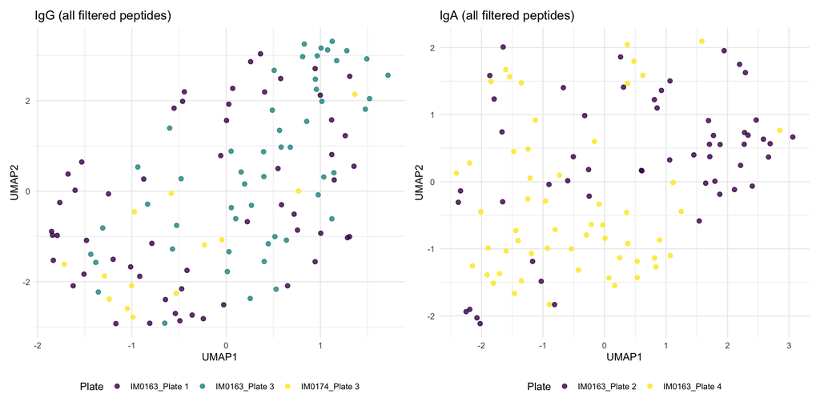

```r
umap_igg_all <- run_umap(igg$values_filtered, igg$metadata)
umap_iga_all <- run_umap(iga$values_filtered, iga$metadata)

p_igg_all <- plot_umap(umap_igg_all, "IgG (all filtered peptides)")
p_iga_all <- plot_umap(umap_iga_all, "IgA (all filtered peptides)")

p_igg_all + p_iga_all
```

## Library-filtered UMAPs (PV2 vs PF3D7)

`class == "PV2"` (P. vivax) vs `class == "PF3D7"` (P. falciparum) further restrict the already `>=3`-samples-Z>6-filtered peptide set from above – not an independent filter.

```r
pf1_annot <- read_csv("../../utils/PF1_annot.csv", show_col_types = FALSE)

pv2_peptides <- pf1_annot %>% filter(class == "PV2") %>% pull(library_member)
pf3d7_peptides <- pf1_annot %>% filter(class == "PF3D7") %>% pull(library_member)

igg_pv2 <- igg$values_filtered %>% filter(library_member %in% pv2_peptides)
igg_pf3d7 <- igg$values_filtered %>% filter(library_member %in% pf3d7_peptides)
iga_pv2 <- iga$values_filtered %>% filter(library_member %in% pv2_peptides)
iga_pf3d7 <- iga$values_filtered %>% filter(library_member %in% pf3d7_peptides)

print(paste0("IgG PV2: ", nrow(igg_pv2), " peptides, PF3D7: ", nrow(igg_pf3d7), " peptides"))
```

```
[1] "IgG PV2: 5941 peptides, PF3D7: 6104 peptides"
```

```r
print(paste0("IgA PV2: ", nrow(iga_pv2), " peptides, PF3D7: ", nrow(iga_pf3d7), " peptides"))
```

```
[1] "IgA PV2: 2402 peptides, PF3D7: 1696 peptides"
```

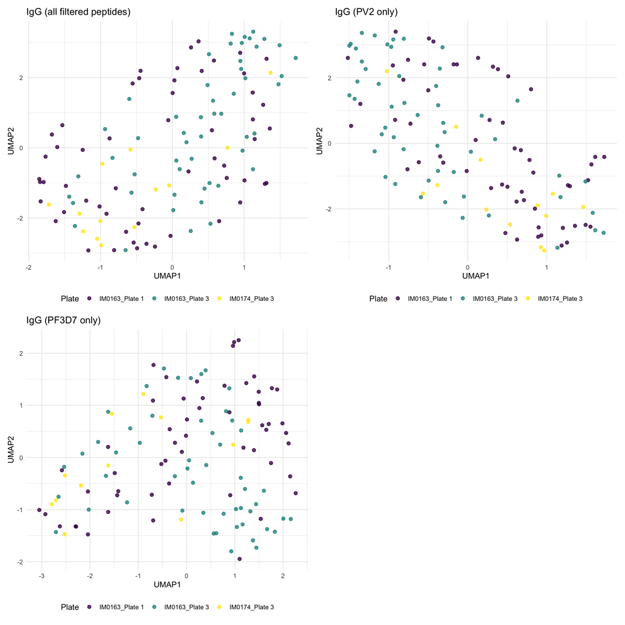

```r
umap_igg_pv2 <- run_umap(igg_pv2, igg$metadata)
umap_igg_pf3d7 <- run_umap(igg_pf3d7, igg$metadata)
umap_iga_pv2 <- run_umap(iga_pv2, iga$metadata)
umap_iga_pf3d7 <- run_umap(iga_pf3d7, iga$metadata)

p_igg_pv2 <- plot_umap(umap_igg_pv2, "IgG (PV2 only)")
p_igg_pf3d7 <- plot_umap(umap_igg_pf3d7, "IgG (PF3D7 only)")
p_iga_pv2 <- plot_umap(umap_iga_pv2, "IgA (PV2 only)")
p_iga_pf3d7 <- plot_umap(umap_iga_pf3d7, "IgA (PF3D7 only)")

# max 2 panels per row
wrap_plots(p_igg_all, p_igg_pv2, p_igg_pf3d7, ncol = 2)
```

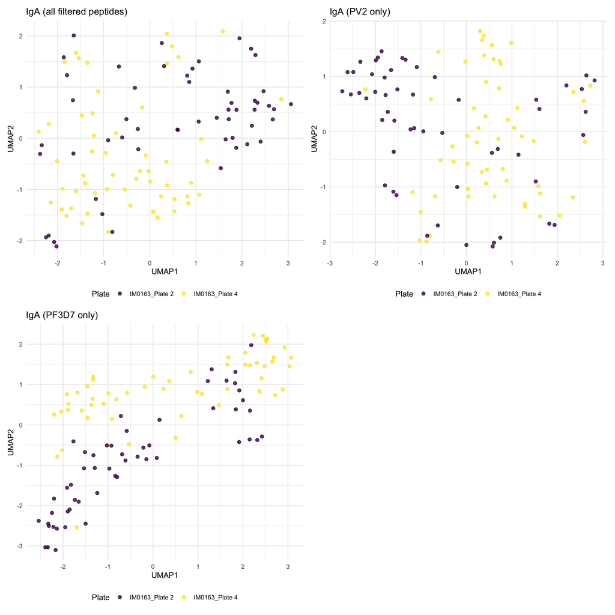

```r
wrap_plots(p_iga_all, p_iga_pv2, p_iga_pf3d7, ncol = 2)
```

## Companion norm-count UMAPs

Same peptide set as the base UMAPs above (`>=3` samples with Z > 6), but run on the companion normalized read counts (`*_qc_norm_counts.tsv`) instead of Z-scores – peptide filtering stays anchored to the Z-score criteria; only the values fed into UMAP change. Peptide ID sets are identical between each isotype’s Z-score and norm-count files, so no `library_member`s are lost re-selecting into the norm-count matrix.

```r
igg_norm <- load_isotype(
  "../../pepsirf_data/data_for_sharing_20250214/IM0166_IM0174_PF1_raw_4mm_IgG_qc_norm_counts.tsv",
  "../../0-sample_tidy/out/20260714/sample_subject_metadata_pepseq_IgG.tsv"
)

iga_norm <- load_isotype(
  "../../pepsirf_data/data_for_sharing_20250214/IM0166_PF1_raw_4mm_IgA_qc_norm_counts.tsv",
  "../../0-sample_tidy/out/20260714/sample_subject_metadata_pepseq_IgA.tsv"
)

igg_norm_filtered <- igg_norm$values %>% filter(library_member %in% igg$values_filtered$library_member)
iga_norm_filtered <- iga_norm$values %>% filter(library_member %in% iga$values_filtered$library_member)

print(paste0("IgG norm counts: ", nrow(igg_norm_filtered), " of ", nrow(igg$values_filtered),
             " Z-filtered peptides found in the norm-count matrix"))
```

```
[1] "IgG norm counts: 13415 of 13415 Z-filtered peptides found in the norm-count matrix"
```

```r
print(paste0("IgA norm counts: ", nrow(iga_norm_filtered), " of ", nrow(iga$values_filtered),
             " Z-filtered peptides found in the norm-count matrix"))
```

```
[1] "IgA norm counts: 4487 of 4487 Z-filtered peptides found in the norm-count matrix"
```

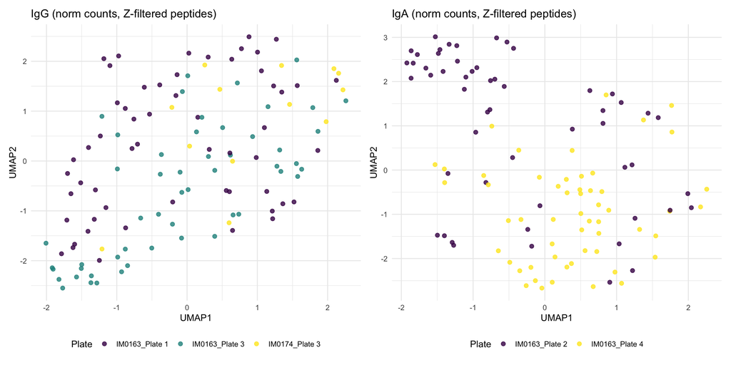

```r
umap_igg_norm <- run_umap(igg_norm_filtered, igg_norm$metadata)
umap_iga_norm <- run_umap(iga_norm_filtered, iga_norm$metadata)

p_igg_norm <- plot_umap(umap_igg_norm, "IgG (norm counts, Z-filtered peptides)")
p_iga_norm <- plot_umap(umap_iga_norm, "IgA (norm counts, Z-filtered peptides)")

p_igg_norm + p_iga_norm
```

## ComBat-seq corrected UMAPs

CLAUDE.md documents that Alexis’s original `ComBat()` run – on raw, untransformed counts, no `mod`/`group` argument – made the plate batch effect *worse* by every diagnostic (0% OOB error, plate fully separable post-correction), and names two untested next steps: run `ComBat_seq` (negative-binomial-based, built for raw counts) directly on raw counts instead, and protect a biological covariate via `group`/`mod` so it isn’t removed alongside the batch effect. This section does both, restricted to the same Z-filtered peptide set used everywhere else in this doc, so the resulting UMAPs are directly comparable to the uncorrected base panels above.

`batch = plate_id` (the run-qualified `IM0163_Plate 3`-style values from the corrected plate join) is the effect under test; `group = cohort` protects Mfera vs Liwonde differences (zero NAs, reasonably balanced across plates in both isotypes).

```r
igg_raw <- load_isotype(
  "../../pepsirf_data/data_for_sharing_20250214/IM0166_IM0174_PF1_raw_4mm_IgG_qc_raw_counts.tsv",
  "../../0-sample_tidy/out/20260714/sample_subject_metadata_pepseq_IgG.tsv"
)

iga_raw <- load_isotype(
  "../../pepsirf_data/data_for_sharing_20250214/IM0166_PF1_raw_4mm_IgA_qc_raw_counts.tsv",
  "../../0-sample_tidy/out/20260714/sample_subject_metadata_pepseq_IgA.tsv"
)

igg_raw_filtered <- igg_raw$values %>% filter(library_member %in% igg$values_filtered$library_member)
iga_raw_filtered <- iga_raw$values %>% filter(library_member %in% iga$values_filtered$library_member)

print(paste0("IgG raw counts: ", nrow(igg_raw_filtered), " of ", nrow(igg$values_filtered),
             " Z-filtered peptides found in the raw-count matrix"))
```

```
[1] "IgG raw counts: 13415 of 13415 Z-filtered peptides found in the raw-count matrix"
```

```r
print(paste0("IgA raw counts: ", nrow(iga_raw_filtered), " of ", nrow(iga$values_filtered),
             " Z-filtered peptides found in the raw-count matrix"))
```

```
[1] "IgA raw counts: 4487 of 4487 Z-filtered peptides found in the raw-count matrix"
```

```r
run_combat_seq <- function(data_wide, metadata) {
  mat <- data_wide %>% select(-library_member) %>% as.matrix()
  rownames(mat) <- data_wide$library_member

  # ComBat_seq's batch/group vectors must align positionally with mat's columns,
  # not just match by set membership -- reorder metadata to match.
  meta_ordered <- metadata %>%
    filter(pepseq_sn %in% colnames(mat)) %>%
    arrange(match(pepseq_sn, colnames(mat)))

  adjusted <- ComBat_seq(
    counts = mat,
    batch = meta_ordered$plate_id,
    group = meta_ordered$cohort
  )

  as_tibble(adjusted, rownames = "library_member")
}

igg_combat <- run_combat_seq(igg_raw_filtered, igg$metadata)
```

```
Found 3 batches
Using full model in ComBat-seq.
Adjusting for 1 covariate(s) or covariate level(s)
Estimating dispersions
Fitting the GLM model
Shrinkage off - using GLM estimates for parameters
Adjusting the data
```

```r
iga_combat <- run_combat_seq(iga_raw_filtered, iga$metadata)
```

```
Found 2 batches
Using full model in ComBat-seq.
Adjusting for 1 covariate(s) or covariate level(s)
Estimating dispersions
Fitting the GLM model
Shrinkage off - using GLM estimates for parameters
Adjusting the data
```

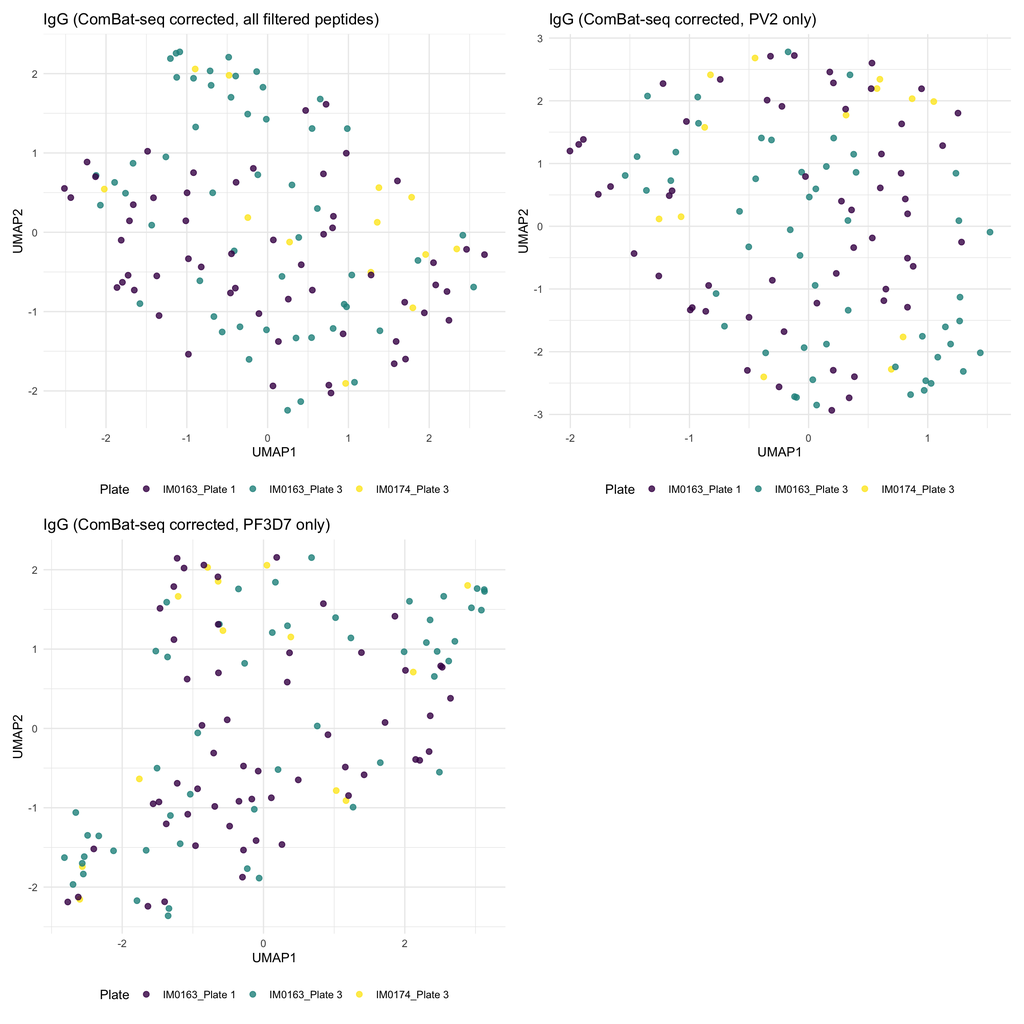

```r
igg_combat_pv2 <- igg_combat %>% filter(library_member %in% pv2_peptides)
igg_combat_pf3d7 <- igg_combat %>% filter(library_member %in% pf3d7_peptides)
iga_combat_pv2 <- iga_combat %>% filter(library_member %in% pv2_peptides)
iga_combat_pf3d7 <- iga_combat %>% filter(library_member %in% pf3d7_peptides)

umap_igg_combat <- run_umap(igg_combat, igg$metadata)
umap_iga_combat <- run_umap(iga_combat, iga$metadata)
umap_igg_combat_pv2 <- run_umap(igg_combat_pv2, igg$metadata)
umap_igg_combat_pf3d7 <- run_umap(igg_combat_pf3d7, igg$metadata)
umap_iga_combat_pv2 <- run_umap(iga_combat_pv2, iga$metadata)
umap_iga_combat_pf3d7 <- run_umap(iga_combat_pf3d7, iga$metadata)

p_igg_combat <- plot_umap(umap_igg_combat, "IgG (ComBat-seq corrected, all filtered peptides)")
p_iga_combat <- plot_umap(umap_iga_combat, "IgA (ComBat-seq corrected, all filtered peptides)")
p_igg_combat_pv2 <- plot_umap(umap_igg_combat_pv2, "IgG (ComBat-seq corrected, PV2 only)")
p_igg_combat_pf3d7 <- plot_umap(umap_igg_combat_pf3d7, "IgG (ComBat-seq corrected, PF3D7 only)")
p_iga_combat_pv2 <- plot_umap(umap_iga_combat_pv2, "IgA (ComBat-seq corrected, PV2 only)")
p_iga_combat_pf3d7 <- plot_umap(umap_iga_combat_pf3d7, "IgA (ComBat-seq corrected, PF3D7 only)")

# max 2 panels per row
wrap_plots(p_igg_combat, p_igg_combat_pv2, p_igg_combat_pf3d7, ncol = 2)
```

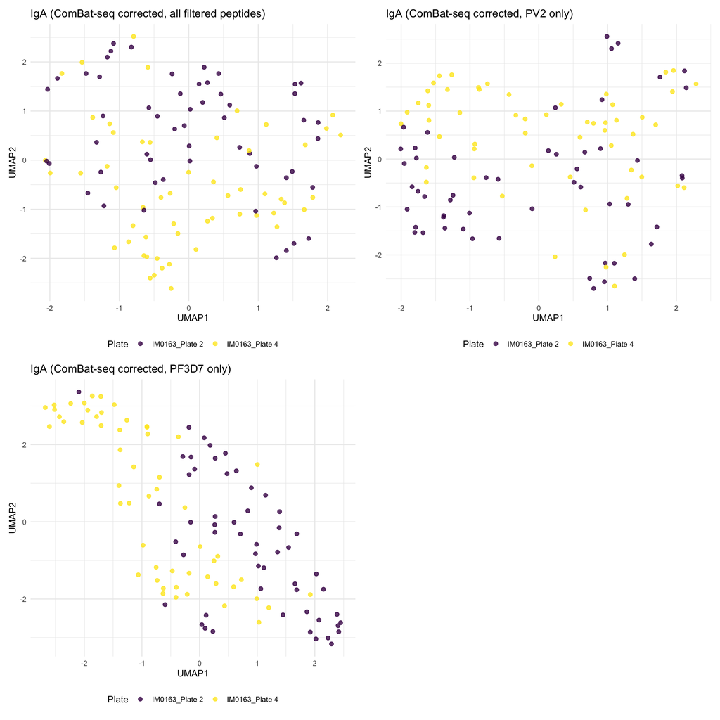

```r
wrap_plots(p_iga_combat, p_iga_combat_pv2, p_iga_combat_pf3d7, ncol = 2)
```

## Outputs

```r
# write_tsv(umap_igg_all, file.path(output_dir, "umap_coords_igg_all.tsv"))
# write_tsv(umap_igg_pv2, file.path(output_dir, "umap_coords_igg_pv2.tsv"))
# write_tsv(umap_igg_pf3d7, file.path(output_dir, "umap_coords_igg_pf3d7.tsv"))
# write_tsv(umap_iga_all, file.path(output_dir, "umap_coords_iga_all.tsv"))
# write_tsv(umap_iga_pv2, file.path(output_dir, "umap_coords_iga_pv2.tsv"))
# write_tsv(umap_iga_pf3d7, file.path(output_dir, "umap_coords_iga_pf3d7.tsv"))
# write_tsv(umap_igg_norm, file.path(output_dir, "umap_coords_igg_norm.tsv"))
# write_tsv(umap_iga_norm, file.path(output_dir, "umap_coords_iga_norm.tsv"))
# write_tsv(umap_igg_combat, file.path(output_dir, "umap_coords_igg_combat.tsv"))
# write_tsv(umap_igg_combat_pv2, file.path(output_dir, "umap_coords_igg_combat_pv2.tsv"))
# write_tsv(umap_igg_combat_pf3d7, file.path(output_dir, "umap_coords_igg_combat_pf3d7.tsv"))
# write_tsv(umap_iga_combat, file.path(output_dir, "umap_coords_iga_combat.tsv"))
# write_tsv(umap_iga_combat_pv2, file.path(output_dir, "umap_coords_iga_combat_pv2.tsv"))
# write_tsv(umap_iga_combat_pf3d7, file.path(output_dir, "umap_coords_iga_combat_pf3d7.tsv"))

# ggsave(file.path(output_dir, "umap_igg_panel.png"), wrap_plots(p_igg_all, p_igg_pv2, p_igg_pf3d7, ncol = 2), width = 12, height = 12)
# ggsave(file.path(output_dir, "umap_iga_panel.png"), wrap_plots(p_iga_all, p_iga_pv2, p_iga_pf3d7, ncol = 2), width = 12, height = 12)
# ggsave(file.path(output_dir, "umap_norm_panel.png"), p_igg_norm + p_iga_norm, width = 12, height = 6)
# ggsave(file.path(output_dir, "umap_igg_combat_panel.png"), wrap_plots(p_igg_combat, p_igg_combat_pv2, p_igg_combat_pf3d7, ncol = 2), width = 12, height = 12)
# ggsave(file.path(output_dir, "umap_iga_combat_panel.png"), wrap_plots(p_iga_combat, p_iga_combat_pv2, p_iga_combat_pf3d7, ncol = 2), width = 12, height = 12)
```